# Lecture 9: Subsetting Data

In this lecture, we will work on subsetting data.

## I. Import Libraries and Read Files

```python
# the "pandas" library is for manipualting datasets
# the "matplotlib.pyplot" library is for creating graphs
import pandas as pd
import matplotlib.pyplot as plt
```

```python
# Read the car features dataset
carfeatures = pd.read_csv("data_raw/features.csv")
```

## II. Basic data display

Display a dataset

- Remember that in VS-Code there is also a data viewer.
- Go to the variables tab at the top of the notebook

```python
# The display() command will show the first 5 rows and the last five rows

display(carfeatures)
```

|  | mpg | cylinders | displacement | horsepower | weight | acceleration | vehicle_id |
| --- | --- | --- | --- | --- | --- | --- | --- |
| 0 | 18.0 | 8 | 307 | 130 | 3504 | 12.0 | C-1689780 |
| 1 | 15.0 | 8 | 350 | 165 | 3693 | 11.5 | B-1689791 |
| 2 | 18.0 | 8 | 318 | 150 | 3436 | 11.0 | P-1689802 |
| 3 | 16.0 | 8 | 304 | 150 | 3433 | 12.0 | A-1689813 |
| 4 | 17.0 | 8 | 302 | 140 | 3449 | 10.5 | F-1689824 |
| ... | ... | ... | ... | ... | ... | ... | ... |
| 393 | 27.0 | 4 | 140 | 86 | 2790 | 15.6 | F-1694103 |
| 394 | 44.0 | 4 | 97 | 52 | 2130 | 24.6 | V-1694114 |
| 395 | 32.0 | 4 | 135 | 84 | 2295 | 11.6 | D-1694125 |
| 396 | 28.0 | 4 | 120 | 79 | 2625 | 18.6 | F-1694136 |
| 397 | 31.0 | 4 | 119 | 82 | 2720 | 19.4 | C-1694147 |

398 rows × 7 columns

Extract column names

```python
# Write the name of the dataset and use a period "." to extract
# the attribute "columns" and the subttribute "values"
# carfeatures.columns - index
# carfeatures.columns.value - array
car_colnames = carfeatures.columns.values
print(car_colnames)
```

```
['mpg' 'cylinders' 'displacement' 'horsepower' 'weight' 'acceleration'
 'vehicle_id']
```

Subset columns:

```
data[list_names]
```

```python
display(carfeatures[["weight","mpg"]])
```

|  | weight | mpg |
| --- | --- | --- |
| 0 | 3504 | 18.0 |
| 1 | 3693 | 15.0 |
| 2 | 3436 | 18.0 |
| 3 | 3433 | 16.0 |
| 4 | 3449 | 17.0 |
| ... | ... | ... |
| 393 | 2790 | 27.0 |
| 394 | 2130 | 44.0 |
| 395 | 2295 | 32.0 |
| 396 | 2625 | 28.0 |
| 397 | 2720 | 31.0 |

398 rows × 2 columns

```python
# To subset multiple columns write the name of the datasets
# and enter a list in square brackets next to the name

list_subsetcols     = ["weight","mpg"]
subcols_carfeatures = carfeatures[list_subsetcols]
display(subcols_carfeatures)

# Or we can simply include the list directly inside square brackets
display(carfeatures[["weight","mpg"]])
```

|  | weight | mpg |
| --- | --- | --- |
| 0 | 3504 | 18.0 |
| 1 | 3693 | 15.0 |
| 2 | 3436 | 18.0 |
| 3 | 3433 | 16.0 |
| 4 | 3449 | 17.0 |
| ... | ... | ... |
| 393 | 2790 | 27.0 |
| 394 | 2130 | 44.0 |
| 395 | 2295 | 32.0 |
| 396 | 2625 | 28.0 |
| 397 | 2720 | 31.0 |

398 rows × 2 columns

|  | weight | mpg |
| --- | --- | --- |
| 0 | 3504 | 18.0 |
| 1 | 3693 | 15.0 |
| 2 | 3436 | 18.0 |
| 3 | 3433 | 16.0 |
| 4 | 3449 | 17.0 |
| ... | ... | ... |
| 393 | 2790 | 27.0 |
| 394 | 2130 | 44.0 |
| 395 | 2295 | 32.0 |
| 396 | 2625 | 28.0 |
| 397 | 2720 | 31.0 |

398 rows × 2 columns

Try it yourself!

- Extract the weight and acceleration variables

```python
# Write your own code

display(carfeatures[["weight","acceleration"]])
```

|  | weight | acceleration |
| --- | --- | --- |
| 0 | 3504 | 12.0 |
| 1 | 3693 | 11.5 |
| 2 | 3436 | 11.0 |
| 3 | 3433 | 12.0 |
| 4 | 3449 | 10.5 |
| ... | ... | ... |
| 393 | 2790 | 15.6 |
| 394 | 2130 | 24.6 |
| 395 | 2295 | 11.6 |
| 396 | 2625 | 18.6 |
| 397 | 2720 | 19.4 |

398 rows × 2 columns

## III. Subsetting by row/column position

Sort by column

```python
carsorted = carfeatures.sort_values(by = "mpg", ascending = False)
display(carsorted)
```

|  | mpg | cylinders | displacement | horsepower | weight | acceleration | vehicle_id |
| --- | --- | --- | --- | --- | --- | --- | --- |
| 322 | 46.6 | 4 | 86 | 65 | 2110 | 17.9 | M-1693322 |
| 329 | 44.6 | 4 | 91 | 67 | 1850 | 13.8 | H-1693399 |
| 325 | 44.3 | 4 | 90 | 48 | 2085 | 21.7 | V-1693355 |
| 394 | 44.0 | 4 | 97 | 52 | 2130 | 24.6 | V-1694114 |
| 326 | 43.4 | 4 | 90 | 48 | 2335 | 23.7 | V-1693366 |
| ... | ... | ... | ... | ... | ... | ... | ... |
| 103 | 11.0 | 8 | 400 | 150 | 4997 | 14.0 | C-1690913 |
| 67 | 11.0 | 8 | 429 | 208 | 4633 | 11.0 | M-1690517 |
| 25 | 10.0 | 8 | 360 | 215 | 4615 | 14.0 | F-1690055 |
| 26 | 10.0 | 8 | 307 | 200 | 4376 | 15.0 | C-1690066 |
| 28 | 9.0 | 8 | 304 | 193 | 4732 | 18.5 | H-1690088 |

398 rows × 7 columns

Subset row(s)

`data.iloc[ row_int , : ]` $\quad$ or

`data.iloc[ list_rows, : ]`

```python
# The following command extracts all columns for row zero
# Remember that numbering starts at zero in Python
# In this case we will show the car with the highest "mpg" value

display(carsorted.iloc[0,:])
display(carsorted.iloc[[0,1,2],:])
```

```
mpg                  46.6
cylinders               4
displacement           86
horsepower             65
weight               2110
acceleration         17.9
vehicle_id      M-1693322
Name: 322, dtype: object
```

|  | mpg | cylinders | displacement | horsepower | weight | acceleration | vehicle_id |
| --- | --- | --- | --- | --- | --- | --- | --- |
| 322 | 46.6 | 4 | 86 | 65 | 2110 | 17.9 | M-1693322 |
| 329 | 44.6 | 4 | 91 | 67 | 1850 | 13.8 | H-1693399 |
| 325 | 44.3 | 4 | 90 | 48 | 2085 | 21.7 | V-1693355 |

Subset block of rows

`data.iloc[ lower:upper , : ]`

```python
# Extract rows 0 to 5
display(carfeatures.iloc[0:5,:])

# Extract rows 8 onwards
display(carfeatures.iloc[ 8:, : ])

# Note: We can leave the numbers to the left and right of ":" blank
# in order to select all values before or after, respectively.
```

|  | mpg | cylinders | displacement | horsepower | weight | acceleration | vehicle_id |
| --- | --- | --- | --- | --- | --- | --- | --- |
| 0 | 18.0 | 8 | 307 | 130 | 3504 | 12.0 | C-1689780 |
| 1 | 15.0 | 8 | 350 | 165 | 3693 | 11.5 | B-1689791 |
| 2 | 18.0 | 8 | 318 | 150 | 3436 | 11.0 | P-1689802 |
| 3 | 16.0 | 8 | 304 | 150 | 3433 | 12.0 | A-1689813 |
| 4 | 17.0 | 8 | 302 | 140 | 3449 | 10.5 | F-1689824 |

|  | mpg | cylinders | displacement | horsepower | weight | acceleration | vehicle_id |
| --- | --- | --- | --- | --- | --- | --- | --- |
| 8 | 14.0 | 8 | 455 | 225 | 4425 | 10.0 | P-1689868 |
| 9 | 15.0 | 8 | 390 | 190 | 3850 | 8.5 | A-1689879 |
| 10 | 15.0 | 8 | 383 | 170 | 3563 | 10.0 | D-1689890 |
| 11 | 14.0 | 8 | 340 | 160 | 3609 | 8.0 | P-1689901 |
| 12 | 15.0 | 8 | 400 | 150 | 3761 | 9.5 | C-1689912 |
| ... | ... | ... | ... | ... | ... | ... | ... |
| 393 | 27.0 | 4 | 140 | 86 | 2790 | 15.6 | F-1694103 |
| 394 | 44.0 | 4 | 97 | 52 | 2130 | 24.6 | V-1694114 |
| 395 | 32.0 | 4 | 135 | 84 | 2295 | 11.6 | D-1694125 |
| 396 | 28.0 | 4 | 120 | 79 | 2625 | 18.6 | F-1694136 |
| 397 | 31.0 | 4 | 119 | 82 | 2720 | 19.4 | C-1694147 |

390 rows × 7 columns

Similar for columns

- One column: $\quad$ `data.iloc[ : , col_integer ]`
- Multiple columns: $\quad$ `data.iloc[ : , list_cols ]`
- Row+Column: $\quad$ `data.iloc[ list_rows , list_cols ]`

Try it yourself!!

- Create a new datate called "car_ascendingmpg" which  
  sorts cars from lowest to highest mpg
- Subset the data of 5 cars with the lowest "mpg"

HINT: Use `sort_values(...,ascending = TRUE`)

```python
# Write your own code

car_ascendingmpg = carfeatures.sort_values(by = "mpg",ascending = True)
display(car_ascendingmpg.iloc[0:5,:])
```

|  | mpg | cylinders | displacement | horsepower | weight | acceleration | vehicle_id |
| --- | --- | --- | --- | --- | --- | --- | --- |
| 28 | 9.0 | 8 | 304 | 193 | 4732 | 18.5 | H-1690088 |
| 25 | 10.0 | 8 | 360 | 215 | 4615 | 14.0 | F-1690055 |
| 26 | 10.0 | 8 | 307 | 200 | 4376 | 15.0 | C-1690066 |
| 103 | 11.0 | 8 | 400 | 150 | 4997 | 14.0 | C-1690913 |
| 124 | 11.0 | 8 | 350 | 180 | 3664 | 11.0 | O-1691144 |

## II. Queries

Filter the data based on its content

```
data.query("logical expression")
```

(i) Expressions with colnames

```python
carfeatures[carfeatures["mpg"]>=25]
# or
carfeatures.query("mpg >= 25")
# extract values of mpg >= 25

carfeatures[(carfeatures["acceleration"]>=10) & (carfeatures["acceleration"]<18)]
# extract values

(carfeatures["acceleration"]>=10) & (carfeatures["acceleration"]<18)
# boolean type
```

```
0       True
1       True
2       True
3       True
4       True
       ...
393     True
394    False
395     True
396    False
397    False
Name: acceleration, Length: 398, dtype: bool
```

```python
# Enter any logical expression
data_threshold_mpg        = carfeatures.query("mpg >= 25")
data_rangeacceleration    = carfeatures.query("(acceleration >= 10) & (acceleration < 18)")
```

(ii) Expressions with colnames + global variables (@)

```python
# You can invoke global variables into the query by using @variablename
# If you don't include @, then Python will try to look for a column with
# that name.

threshold = 25
data_varthreshold_mpg = carfeatures.query("mpg >= @threshold")
```

(iii) Expressions with colnames with spaces

```python
# Sometimes column names have spaces in them
# In this case use the "`" symbol, e.g.          `variable name`

carfeatures["new variable"] = carfeatures["mpg"]
data_spacesthreshold_mpg = carfeatures.query("`new variable` >= 25")
```

```python
carfeatures["new variable two"] = carfeatures["mpg"]
data_spacesthreshold_mpg_two = carfeatures.query("`new variable two` >= 25")
```

Try it yourself!

- Subset the data with mpg $\ge$ 25 and cylinders == 8

```python
# Write your own code here

data_mpg_cylinders = carfeatures.query("(mpg >= 25) and (cylinders == 8)")

mpg_threshold = 25
cylinders_threshold = 8
data_mpg_cylinders = carfeatures.query("(mpg >= @mpg_threshold) and (cylinders == @cylinders_threshold)")
```

## III. Visualization for Subsets of the Data

List of unique categories

```python
# Use pd.unique() to extract a list with the unique elements in that column

list_unique_cylinders = pd.unique(carfeatures["cylinders"])
print(list_unique_cylinders)
```

```
[8 4 6 3 5]
```

Compute two overlapping plots

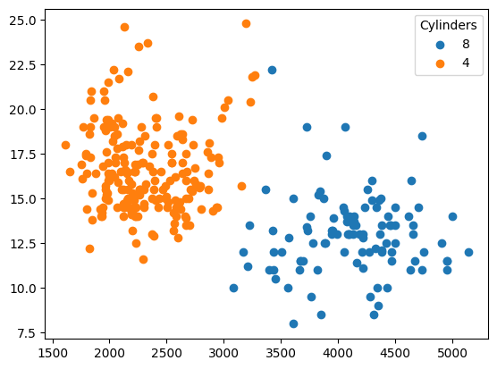

```python
# If we call plt.scatter() twice to display two plots
# To display all plots simultaneously we include plt.show() at the very end.
# The idea is that the graphs are stacked on top of each other

df_8 = carfeatures.query("cylinders == 8")
df_4 = carfeatures.query("cylinders == 4")

plt.scatter(x = df_8["weight"],y = df_8["acceleration"])
plt.scatter(x = df_4["weight"],y = df_4["acceleration"])
plt.legend(labels = ["8","4"],
           title  = "Cylinders")

plt.show()

# Note: If we put plt.show() in between the plots, then the results will
# be shown on separate graphs instead.
```

Compute plots by all categories

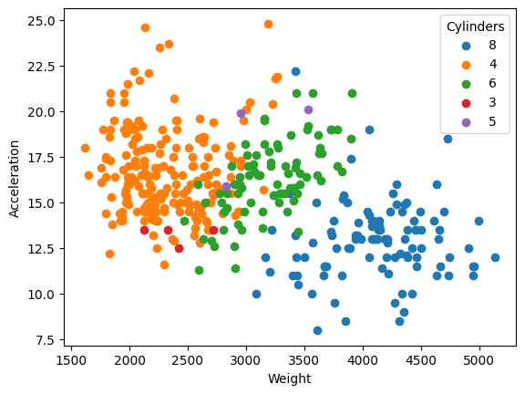

```python
# Compute number of unique categories
list_unique_cylinders = pd.unique(carfeatures["cylinders"])

# Use a for loop to plot a scatter plot between "weight" and "acceleration"
# for each category. Each plot  will have a different color

for category in list_unique_cylinders:
    df   = carfeatures.query("cylinders == @category")
    plt.scatter(x = df["weight"],y = df["acceleration"])

# Add labels and a legends
plt.xlabel("Weight")
plt.ylabel("Acceleration")
plt.legend(labels = list_unique_cylinders,
           title  = "Cylinders")
plt.show()
```

Try it yourself!

- Compute a histogram of "mpg" by cylinder count
- Make the histograms transparent by adjusting `alpha` in

`plt.hist(x = ..., alpha = 0.5)`

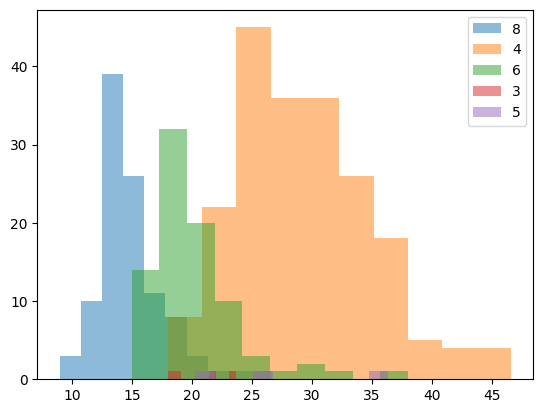

```python
# Write your own code

list_unique_cylinders = pd.unique(carfeatures["cylinders"])

for category_value in list_unique_cylinders:
    temporarydataframe = carfeatures.query("cylinders == @category_value")
    plt.hist(temporarydataframe["mpg"],alpha = 0.5)

plt.legend(labels = list_unique_cylinders)
```